# PADP_8120_Lab4: Random Variables and Distributions

Tyler Scott

2015-08-03

## Lab Topics

### Subject Area

- Distributions in R
- Sampling

### R Methods

- Simulation
- Sampling
- Piping
- Loops

## Goals:

After this lab you will be able to:

- simulate distributions of random variables in R
- perform sampling in R
- use piping to integrate several functions into one call
- write a basic loop

This lab is adapted from materials by:

- Andrew Bray and Mine Cetinkaya-Rundel
- Christopher Gandrud

# Basic loops

### Using a for loop

In many coding situations you will want to create an iterative loop so that your computer can cycle through a task automatically rather than you having to write it all out by hand. The most basic way to do this is using a for loop in R — there are some other ways we can do this using while and repeat which we shall cover in the next class.

##### Example: A basic loop to sum integers

```r
x <- 0 # Counter initialised to zero
a <- 1:10
for(i in a) {
print(i)
x <- x + i
}
x
```

#### Syntax

for(variable in sequence) statement - There will be one iteration of the statement for each component of the vector sequence, with variable taking on the values of those components.

- The statement can itself be compound i.e. include several commands in which case you need to enclose it in brackets `for(variable in sequence) {statement}`

#### Shortening

In the above example we created the sequence first i.e. `a <- 1:n` and then set `i` to cycle through it in the `for()` statement. To be more concise, you can just enter the sequence you want to use directly in the loop itself:

```r
for(i in 1:10) {
print(i)
}
```

1. Write a simple loop that draws 10 different values from the `t` distribution (hint: `rt()`)

```r
fill.vector = NA #make object to store the random values I draw
df.value = 30 #t-distribution requires a df value, since width of distribution (how heavy tails are) is determined by df

# loop through values 1:10, draw 1 random value from t-dist with df = 30, assign to ith spot in the fill.vector object
for (i in 1:10)
{
  fill.vector[i] = rt(1,df=df.value)
}
print(fill.vector)
```

```
##  [1] -1.85785037 -0.03280854  0.01708071  0.09166298  0.29996367
##  [6]  0.59189946  0.52087098 -0.15505892 -0.35220654 -0.18702760
```

## if and if else statements

Often when in the loop of a function you will want to do different things depending upon the iteration you are on. You can do this using the `if` statement

### If Else statements

```r
x <- c(-3, 5, 12)
y <- rep(NA, length(x))
for(i in 1:length(x)) {
if(x[i] >= 0) {
y[i] <- x[i]
} else {
y[i] <- -x[i]
}
}
y
```

#### Syntax

- if (condition) true.branch else false.branch
- The else part is optional and the true.branch or false.branch can be compound statements enclosed in { }.

## Loop caveats

- Avoid vector conditions
- You need to be careful when you are evaluating conditions in R, particularly within an `if` statement.
- When writing a loop, make sure that:
  - the condition you are evaluating is only of length 1
  - when you have any condition it takes a single TRUE or FALSE value.

For example try running

```r
x <- c(1,-2,3)
if(x < 0) print("Hi!")
```

2. Why doesn’t this work?

This does not work because `x` is an object that contains three numbers (1, -2, and 3). Thus, when we ask R to evaluate the question, “Is X < 0?”, R doesn’t know what to do since there isn’t just one answer.

```r
x <- c(-1, 2, -3)
if(x < 0) print("Hi!")
```

3. What about this error? What R does in this situation is use only the first condition value and a warning is issued.

This is actually the same error; the difference is, in the prior example, when R tries to evaluate “Is x < 0?”, the first number it queries produces a FALSE response (since 1 is not less than 0). Since the response is FALSE, R does not print “hi”. Then, R realizes that x contains two more values, and gives an error. In the latter example, the answer to the first value (i.e., x[1]) is TRUE, so R prints “hi”, and then chokes when it realizes that there are two more values associated with x.

4. Write an `if` `else` loop that takes 10 random samples from the standard normal distribution (hint: `rnorm()`), and print the character string “positive” if the sampled value is greater than 0 and “negative” if the sampled value is less than 0.

```r
for (i in 1:10)
{
  if (rnorm(1)>0) {print('positive')}
  else {print('negative')}
}
```

```
## [1] "positive"
## [1] "positive"
## [1] "positive"
## [1] "positive"
## [1] "positive"
## [1] "negative"
## [1] "positive"
## [1] "positive"
## [1] "negative"
## [1] "negative"
```

Note that we could also do this another way, by having R generate 10 random samples and then using the `ifelse` function as a shortcut. The `ifelse` function takes three inputs: (1) the object to iterate over; (2) what do if the condition is TRUE for a given iteraction; and (3) what to do if the condition is FALSE for a given iteration. Note that here we won’t need to specify the `print` function, because `ifelse` returns the specified value based upon the TRUE/FALSE evaluation.

```r
ifelse(rnorm(10)>0,'positive','negative')
```

```
##  [1] "negative" "negative" "positive" "positive" "positive" "positive"
##  [7] "positive" "negative" "negative" "negative"
```

### Breaking a loop

Sometimes you might want to end a loop early if a certain condition has been met. In this case we use the break command. This will cause the computer to jump out of the loop when the break is encountered.

```r
# The break command
for(i in 1:10) {
print(i)
if(i == 7) break
}
i
```

5. Write a loop that draws ten values from a uniform distribution between 0 and 10, and “breaks” when a value is drawn that is greater than 8.

```r
for(i in 1:10) {
  print(i)
  if(runif(n=1,min=0,max=10)>8) break
}
```

### “Nexting” a loop

Alternatively we may wish to sometimes just skip to the next iteration of the loop in which case we would want to use the next command:

```r
for(i in 1:10) {
if(i == 7) next # Skip all lines below this and start next loop iteration
print(i)
}
```

6. Write a loop that uses a `next` command to skip something (of your choice).

```r
color.list <- c('red','blue','green','yellow')
for (i in color.list)
{
  if (i == 'green') next
  print(i)
}
```

```
## [1] "red"
## [1] "blue"
## [1] "yellow"
```

# Normal Distribution

Now, let’s move on to a different subject, the normal distribution. We’ll be working with measurements of body dimensions. This data set contains measurements from 247 men and 260 women, most of whom were considered healthy young adults.

Let’s take a quick peek at the first few rows of the data.

```r
head(bdims)
```

You’ll see that for every observation we have 25 measurements, many of which are either diameters or girths. A key to the variable names can be found at http://www.openintro.org/stat/data/bdims.php, but we’ll be focusing on just three columns to get started: weight in kg (`wgt`), height in cm (`hgt`), and `sex` (`1` indicates male, `0` indicates female).

Since males and females tend to have different body dimensions, it will be useful to create two additional data sets: one with only men and another with only women.

7. Make a histogram (`hist()`) of men’s heights and a histogram of women’s heights. How would you compare the various aspects of the two distributions?

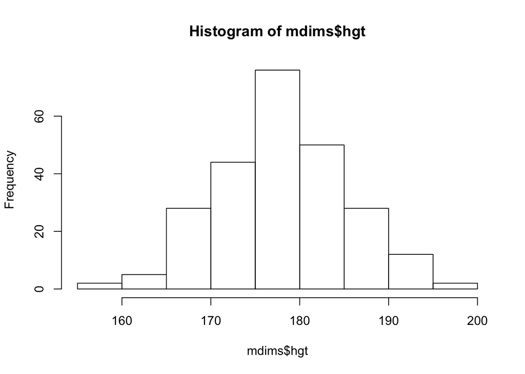

```r
hist(mdims$hgt)
```

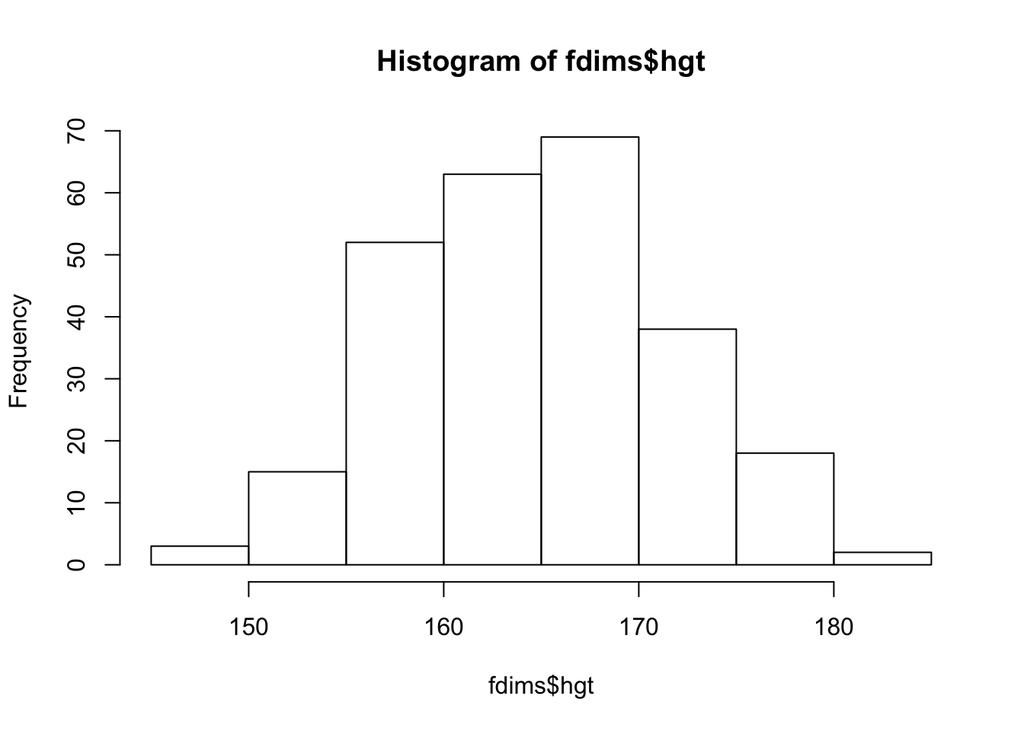

```r
hist(fdims$hgt)
```

Note that ggplot has a quick way to perform the above operations without prior subsetting:

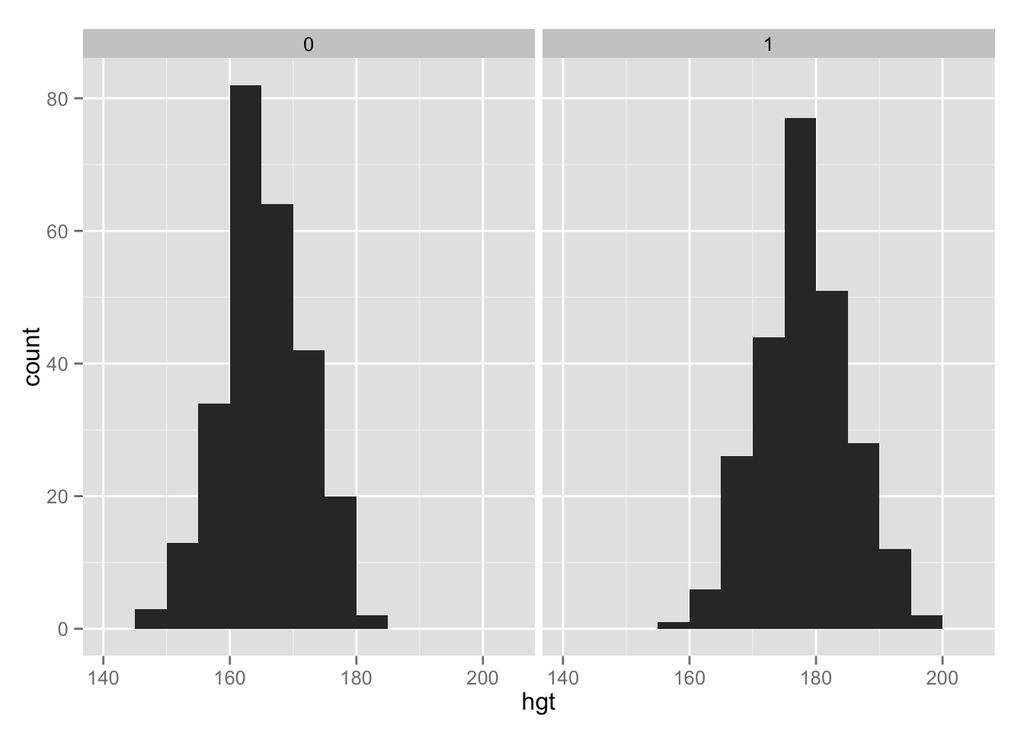

```r
library(ggplot2)
ggplot(bdims, aes(x=hgt)) + geom_histogram(binwidth=5)+ facet_wrap(~sex)
```

In any case, both distributions are approximately a normal distribution. As we might epect, the average male height is a bit taller.

## The normal distribution

We can plot a normal distribution curve on top of a histogram to see how closely the data follow a normal distribution. This normal curve should have the same mean and standard deviation as the data. We’ll be working with women’s heights, so let’s store them as a separate object and then calculate some statistics that will be referenced later.

Next we make a density histogram to use as the backdrop and use the `lines` function to overlay a normal probability curve. The difference between a frequency histogram and a density histogram is that while in a frequency histogram the *heights* of the bars add up to the total number of observations, in a density histogram the *areas* of the bars add up to 1. The area of each bar can be calculated as simply the height *times* the width of the bar. Using a density histogram allows us to properly overlay a normal distribution curve over the histogram since the curve is a normal probability density function. Frequency and density histograms both display the same exact shape; they only differ in their y-axis. You can verify this by comparing the frequency histogram you constructed earlier and the density histogram created by the commands below.

```r
hist(fdims$hgt, probability = TRUE)
x <- 140:190
y <- dnorm(x = x, mean = fhgtmean, sd = fhgtsd)
lines(x = x, y = y, col = "blue")
```

[output not shown]

After plotting the density histogram with the first command, we create the x- and y-coordinates for the normal curve. We chose the `x` range as 140 to 190 in order to span the entire range of `fheight`. To create `y`, we use `dnorm` to calculate the density of each of those x-values in a distribution that is normal with mean `fhgtmean` and standard deviation `fhgtsd`. The final command draws a curve on the existing plot (the density histogram) by connecting each of the points specified by `x` and `y`. The argument `col` simply sets the color for the line to be drawn. If we left it out, the line would be drawn in black.

The top of the curve is cut off because the limits of the x- and y-axes are set to best fit the histogram. To adjust the y-axis you can add a third argument to the histogram function: `ylim = c(0, 0.06)`.

8. Based on the this plot, does it appear that the data follow a nearly normal distribution?

Yes, as we thought before, when we print a normal curve on top of the histogram, it’s clear that the height distribution is nearly normal.

## Evaluating the normal distribution

Eyeballing the shape of the histogram is one way to determine if the data appear to be nearly normally distributed, but it can be frustrating to decide just how close the histogram is to the curve. An alternative approach involves constructing a normal probability plot, also called a normal Q-Q plot for “quantile-quantile”.

```r
qqnorm(fdims$hgt)
qqline(fdims$hgt)
```

[output not shown]

A data set that is nearly normal will result in a probability plot where the points closely follow the line. Any deviations from normality leads to deviations of these points from the line. The plot for female heights shows points that tend to follow the line but with some errant points towards the tails. We’re left with the same problem that we encountered with the histogram above: how close is close enough?

A useful way to address this question is to rephrase it as: what do probability plots look like for data that I *know* came from a normal distribution? We can answer this by simulating data from a normal distribution using `rnorm`.

```r
sim_norm <- rnorm(n = length(fdims$hgt), mean = fhgtmean, sd = fhgtsd)
```

The first argument indicates how many numbers you’d like to generate, which we specify to be the same number of heights in the `fdims` data set using the `length` function. The last two arguments determine the mean and standard deviation of the normal distribution from which the simulated sample will be generated. We can take a look at the shape of our simulated data set, `sim_norm`, as well as its normal probability plot.

9. Make a normal probability plot of `sim_norm`. Do all of the points fall on the line? How does this plot compare to the probability plot for the real data?

```r
qqnorm(sim_norm)
qqline(sim_norm)
```

[output not shown]

As we might expect, the simulated data fit the qqline a little more perfectly, which makes sense since these values were drawn from a normal distribution.

Even better than comparing the original plot to a single plot generated from a normal distribution is to compare it to many more plots using the following function. It may be helpful to click the zoom button in the plot window.

```r
qqnormsim(fdims$hgt)
```

[output not shown]

10. Does the normal probability plot for `fdims$hgt` look similar to the plots created for the simulated data? That is, do plots provide evidence that the female heights are nearly normal?

Actually, yeah it does. In fact, it’s basically impossible to tell the difference between the qq plot of the female height data and the plots for simulated data. This is pretty convincing evidence of normality, because it indicates that even a perfectly normal distribution will have about as much sampling variability as we see in the actual data.

11. Using the same technique, determine whether or not female weights appear to come from a normal distribution.

# Sampling Distributions

Next, let’s investigate the ways in which the statistics from a random sample of data can serve as point estimates for population parameters. We’re interested in formulating a *sampling distribution* of our estimate in order to learn about the properties of the estimate, such as its distribution.

## The data

We consider real estate data from the city of Ames, Iowa. The details of every real estate transaction in Ames is recorded by the City Assessor’s office. Our particular focus for this lab will be all residential home sales in Ames between 2006 and 2010. This collection represents our population of interest. In this lab we would like to learn about these home sales by taking smaller samples from the full population. Let’s load the data.

```r
download.file("http://www.openintro.org/stat/data/ames.RData", destfile = "ames.RData")
load("ames.RData")
```

```r
load('input/ames.RData')
```

We see that there are quite a few variables in the data set, enough to do a very in-depth analysis. For this lab, we’ll restrict our attention to just two of the variables: the above ground living area of the house in square feet (`Gr.Liv.Area`) and the sale price (`SalePrice`). To save some effort throughout the lab, create two variables with short names that represent these two variables.

```r
area <- ames$Gr.Liv.Area
price <- ames$SalePrice
```

Let’s look at the distribution of area in our population of home sales by calculating a few summary statistics and making a histogram.

```r
summary(area)
hist(area)
```

12. Describe this population distribution.

```r
summary(area)
```

```
##    Min. 1st Qu.  Median    Mean 3rd Qu.    Max.
##     334    1126    1442    1500    1743    5642
```

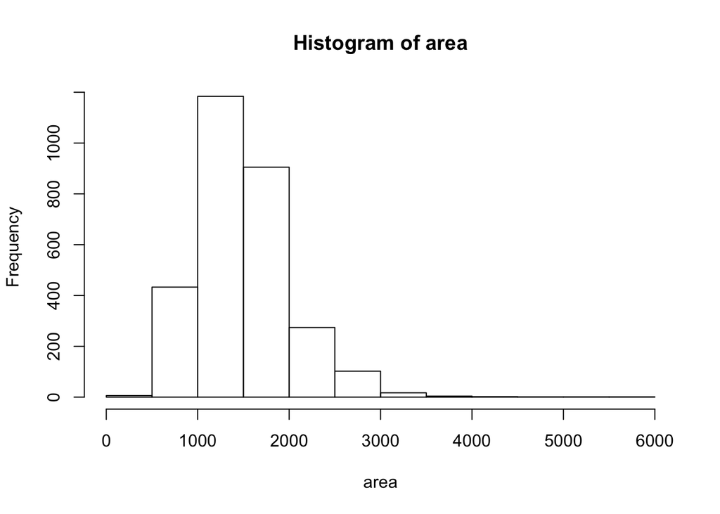

```r
hist(area)
```

These data look fairly normal as well. However, there appears to be a slight rightward skew - this makes sense, since houses cannot have LESS than 0 square feet, but someone can certainly have a huge mansion that has far more square feet than average.

## The unknown sampling distribution

In this lab we have access to the entire population, but this is rarely the case in real life. Gathering information on an entire population is often extremely costly or impossible. Because of this, we often take a sample of the population and use that to understand the properties of the population.

If we were interested in estimating the mean living area in Ames based on a sample, we can use the following command to survey the population.

```r
samp1 <- sample(area, 50)
```

This command collects a simple random sample of size 50 from the vector `area`, which is assigned to `samp1`. This is like going into the City Assessor’s database and pulling up the files on 50 random home sales. Working with these 50 files would be considerably simpler than working with all 2930 home sales.

13. Describe the distribution of this sample. How does it compare to the distribution of the population?

If we’re interested in estimating the average living area in homes in Ames using the sample, our best single guess is the sample mean.

```r
mean(samp1)
```

```
## [1] 1492.14
```

Depending on which 50 homes you selected, your estimate could be a bit above or a bit below the true population mean of 1499.69 square feet. In general, though, the sample mean turns out to be a pretty good estimate of the average living area, and we were able to get it by sampling less than 3% of the population.

14. Take a second sample, also of size 50, and call it `samp2`. How does the mean of `samp2` compare with the mean of `samp1`? Suppose we took two more samples, one of size 100 and one of size 1000. Which would you think would provide a more accurate estimate of the population mean?

```r
samp2 <- sample(area, 50)
mean(samp1)
```

```
## [1] 1492.14
```

```r
mean(samp2)
```

```
## [1] 1534.54
```

Of course, the two sample means are different. The typical difference should decrease as we go to 100 and then 1000 (but might not in very case, since the results are still subject to random variation).

```r
n = 100
samp1 <- sample(area, n)
samp2 <- sample(area, n)
mean(samp1)
```

```
## [1] 1533.97
```

```r
mean(samp2)
```

```
## [1] 1451.84
```

```r
n = 1000
samp1 <- sample(area, n)
samp2 <- sample(area, n)
mean(samp1)
```

```
## [1] 1496.844
```

```r
mean(samp2)
```

```
## [1] 1494.928
```

Not surprisingly, every time we take another random sample, we get a different sample mean. It’s useful to get a sense of just how much variability we should expect when estimating the population mean this way. The distribution of sample means, called the *sampling distribution*, can help us understand this variability. In this lab, because we have access to the population, we can build up the sampling distribution for the sample mean by repeating the above steps many times. Here we will generate 5000 samples and compute the sample mean of each.

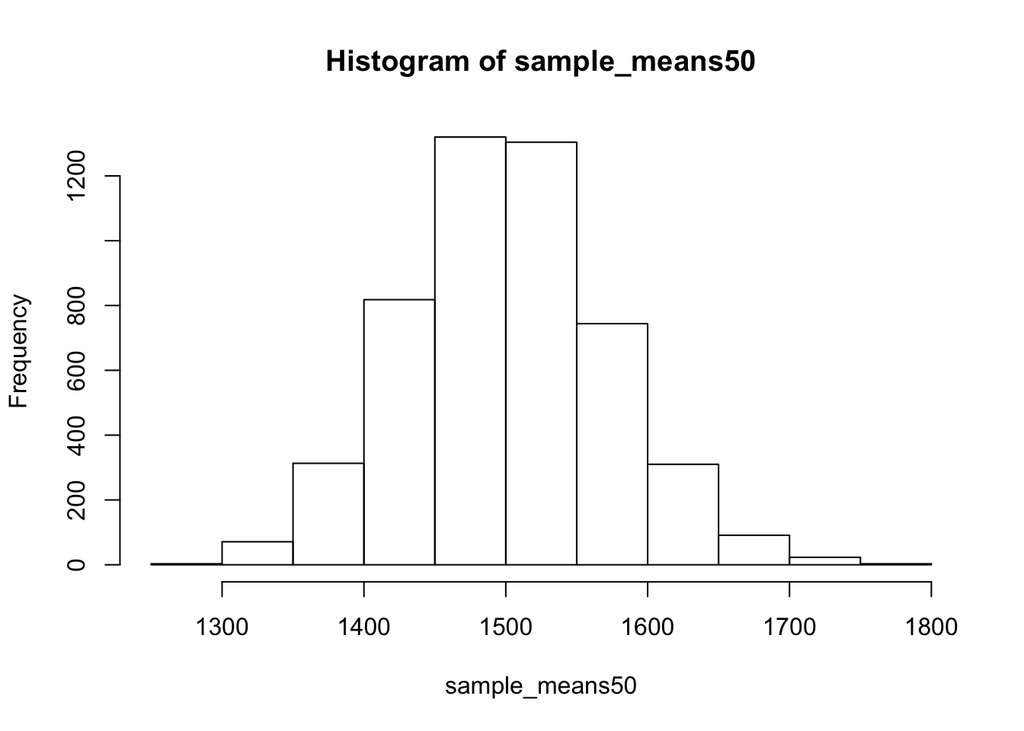

```r
sample_means50 <- rep(NA, 5000)

for(i in 1:5000){
   samp <- sample(area, 50)
   sample_means50[i] <- mean(samp)
   }

hist(sample_means50)
```

If you would like to adjust the bin width of your histogram to show a little more detail, you can do so by changing the `breaks` argument.

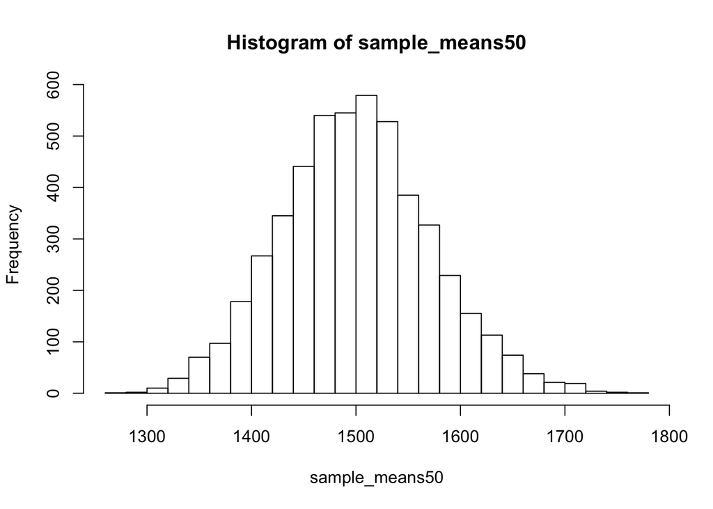

```r
hist(sample_means50, breaks = 25)
```

Here we use R to take 5000 samples of size 50 from the population, calculate the mean of each sample, and store each result in a vector called `sample_means50`.

15. How many elements are there in `sample_means50`? Describe the sampling distribution, and be sure to specifically note its center. Would you expect the distribution to change if we instead collected 50,000 sample means?

```r
str(sample_means50)
```

```
##  num [1:5000] 1435 1531 1527 1446 1475 ...
```

There are 5000 values. The distribution (below) looks basically normal. Most importantly, it appears to be basically centered around the population mean (pop. mean = 1499.6904437, shown with a red dashed line below:

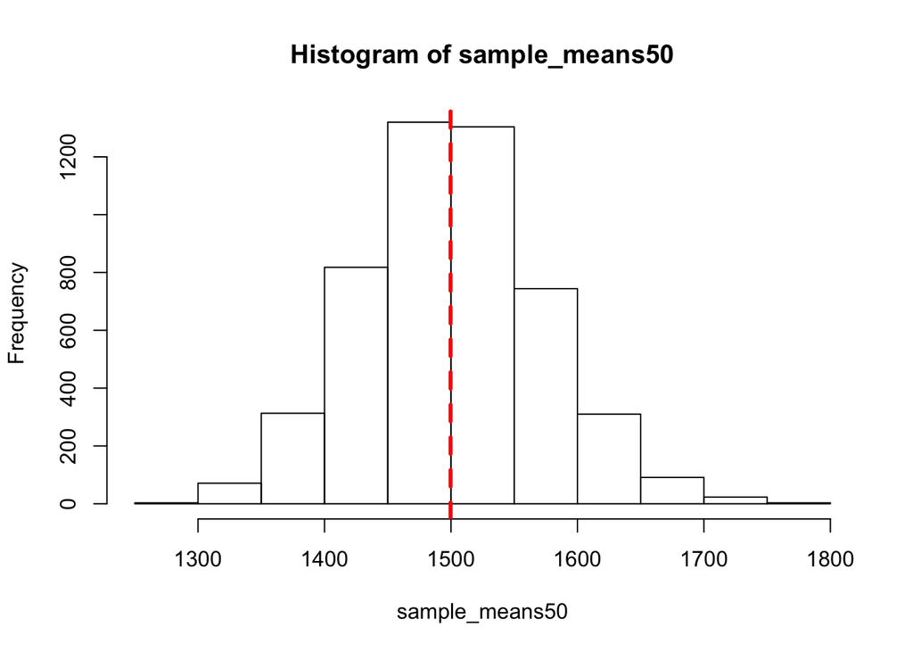

```r
hist(sample_means50)
abline(v = mean(area),col='red',lwd=3,lty=2)
```

In reality, the distribution probably wouldn’t change too much if we collected 50,000 instead of 5,000 sample means, because 5,000 is a lot and because sample means vary less than individual observations (that is, n = 5000 vs. n = 50,000 might produce very different distributions, but when you take 5000 samples of 50, you end up with a pretty large sample size anyways).

## Back to the `for` loop

Let’s review the `for` loop in the context of this example. Again, the idea behind the for loop is *iteration*: it allows you to execute code as many times as you want without having to type out every iteration.

```r
sample_means50 <- rep(NA, 5000)

for(i in 1:5000){
   samp <- sample(area, 50)
   sample_means50[i] <- mean(samp)
   }
```

The second line calls the `for` loop itself. The syntax can be loosely read as, “for every element `i` from 1 to 5000, run the following lines of code”. You can think of `i` as the counter that keeps track of which loop you’re on. Therefore, more precisely, the loop will run once when `i = 1`, then once when `i = 2`, and so on up to `i = 5000`.

The body of the `for` loop is the part inside the curly braces, and this set of code is run for each value of `i`. Here, on every loop, we take a random sample of size 50 from `area`, take its mean, and store it as the $i$<sup>th</sup> element of `sample_means50`.

The `for` loop allows us to not just run the code 5000 times, but to neatly package the results, element by element, into the empty vector that we initialized at the outset.

16. To make sure you understand what you’ve done in this loop, try running a smaller version. Initialize a vector of 100 zeros called `sample_means_small`. Run a loop that takes a sample of size 50 from `area` and stores the sample mean in `sample_means_small`, but only iterate from 1 to 100. Print the output to your screen (type `sample_means_small` into the console and press enter). How many elements are there in this object called `sample_means_small`? What does each element represent?

```r
sample_means_small = rep(0,100)

for (i in 1:length(sample_means_small))
{
  sample_means_small[i] <- mean(sample(area,50))
}
sample_means_small
```

```
##   [1] 1572.62 1456.50 1493.34 1518.94 1418.18 1475.30 1405.78 1493.20
##   [9] 1580.40 1639.00 1430.42 1383.70 1471.56 1580.28 1542.58 1483.96
##  [17] 1501.70 1372.32 1453.64 1472.76 1528.82 1505.96 1422.90 1433.48
##  [25] 1442.72 1430.24 1521.68 1460.58 1407.00 1532.24 1464.60 1546.02
##  [33] 1437.80 1505.72 1491.24 1566.34 1502.46 1396.30 1490.22 1490.36
##  [41] 1529.04 1505.26 1450.90 1623.44 1591.90 1445.60 1474.24 1421.56
##  [49] 1555.68 1532.20 1538.70 1494.88 1384.32 1478.40 1439.64 1429.64
##  [57] 1435.86 1523.10 1439.88 1354.90 1564.68 1484.34 1409.60 1402.80
##  [65] 1541.94 1479.18 1523.90 1439.08 1623.96 1484.48 1581.56 1489.50
##  [73] 1575.90 1502.36 1429.22 1615.54 1516.80 1470.14 1456.94 1535.42
##  [81] 1510.96 1438.44 1571.52 1419.88 1431.16 1428.98 1498.38 1398.46
##  [89] 1420.70 1679.60 1576.66 1455.20 1632.80 1474.66 1416.18 1584.84
##  [97] 1614.44 1469.66 1589.34 1421.68
```

There are 100 elements, each of which represents the mean of a sample of 50 houses in Ames.